# Logistic Regression

## Recap: Linear vs Logistic Regression

**Linear Regression Problems for Classification:**

- Predictions can be outside [0,1] range
- Assumes linear relationship between predictors and probability
- Residuals don’t follow normal distribution for binary outcomes

**Logistic Regression Solution:**

- Uses logistic (sigmoid) function to map any real number to [0,1]
- Models log-odds (logit) as linear combination of predictors
- Provides probabilities that can be converted to classifications

## The Logistic Function

The logistic function transforms any real number to a probability between 0 and 1:

\[p(X) = \frac{e^{\beta_0 + \beta_1 X}}{1 + e^{\beta_0 + \beta_1 X}}\]

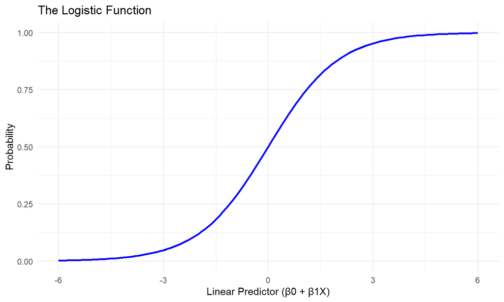

## From Probability to Odds

**Odds:** \(\text{Odds} = \frac{p}{1-p} = e^{\beta_0 + \beta_1 X} = e^{\beta_0} e^{\beta_1 X}\)

- A 1 unit increase in \(X\) multiplies the odds by \(e^{\beta_1}\)

**Log-Odds (Logit):** \(\text{logit}(p) = \log\left(\frac{p}{1-p}\right) = \beta_0 + \beta_1 X\)

- A 1 unit increase in \(X\) increases log-odds by \(\beta_1\)

Example:

```
  Probability Odds Log_Odds
1         0.1 0.11    -2.20
2         0.3 0.43    -0.85
3         0.5 1.00     0.00
4         0.7 2.33     0.85
5         0.9 9.00     2.20
```

- The downside of Logit is that it is harder to interpret
- At least the sign (postive/negative) tell us if probability goes up or down

Comparison: **Linear regression** \(Y = \beta_0 + \beta_1 X\)

## Dataset Exploration (Review)

```r
> data(Default, package = "ISLR2")
> head(Default)
  default student   balance    income
1      No      No  729.5265 44361.625
2      No     Yes  817.1804 12106.135
3      No      No 1073.5492 31767.139
4      No      No  529.2506 35704.494
5      No      No  785.6559 38463.496
6      No     Yes  919.5885  7491.559
>
> Default %>% count(default) %>% mutate(proportion = n / sum(n))
  default    n proportion
1      No 9667     0.9667
2     Yes  333     0.0333
```

Quick review: 10000 observations, 333 defaults (3.3%).

## Logistic Regression Model

- Syntax is similar to linear regression but use `family=binomial`

```r
> model_logistic <- glm(default ~ balance + income, data = Default, family = binomial)
> summary(model_logistic)

Call:
glm(formula = default ~ balance + income, family = binomial,
    data = Default)

Coefficients:
                 Estimate    Std. Error z value             Pr(>|z|)
(Intercept) -11.540468437   0.434756357 -26.545 < 0.0000000000000002 ***
balance       0.005647103   0.000227373  24.836 < 0.0000000000000002 ***
income        0.000020809   0.000004985   4.174            0.0000299 ***
---
Signif. codes:  0 '***' 0.001 '**' 0.01 '*' 0.05 '.' 0.1 ' ' 1

(Dispersion parameter for binomial family taken to be 1)

    Null deviance: 2920.6  on 9999  degrees of freedom
Residual deviance: 1579.0  on 9997  degrees of freedom
AIC: 1585

Number of Fisher Scoring iterations: 8
```

## Interpreting Coefficients

- `tidy()` converts model output to readable table

```r
> coef_summary <- tidy(model_logistic)
> coef_summary$odds_ratio <- exp(coef_summary$estimate)
> coef_summary %>% select(term, estimate, odds_ratio, p.value)
# A tibble: 3 × 4
  term           estimate odds_ratio   p.value
  <chr>             <dbl>      <dbl>     <dbl>
1 (Intercept) -11.5       0.00000973 2.96e-155
2 balance       0.00565   1.01       3.64e-136
3 income        0.0000208 1.00       2.99e-  5
```

**Key insight:**

- **Balance:** Each $1 increase multiplies odds by 1.0057
- **Income:** Each $1 increase multiplies odds by 1

## Predictions and Probabilities

- Probability formula: \(p(X) = \tfrac{e^{\beta_0 + \beta_1 balance+\beta_2 income}}{1+e^{\beta_0 + \beta_1 balance+\beta_2 income}}\)
- Use model to predict probabilities

```r
> Default$prob_logistic <- predict(model_logistic, type="response")
> Default %>% select(default, balance, income, prob_logistic) %>% arrange(desc(prob_logistic)) %>% head(10)
   default  balance   income prob_logistic
1      Yes 2654.323 21930.39     0.9802589
2      Yes 2499.017 51504.29     0.9745060
3      Yes 2578.469 25706.65     0.9722220
4       No 2391.008 50302.91     0.9529589
5      Yes 2502.685 14947.52     0.9480189
6      Yes 2413.319 38540.57     0.9473391
7      Yes 2343.798 51095.29     0.9403881
8      Yes 2461.507 11878.56     0.9313168
9      Yes 2387.315 28296.91     0.9262029
10     Yes 2288.408 52043.57     0.9216790
```

## Visualizing Probabilities by Balance

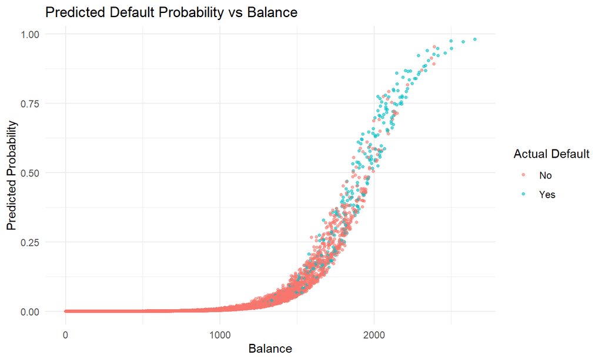

- Higher balance = higher probability of default in the model
- The higher probability in the model is correlated with actual default
- A few misses here and there

## Visualizing Probabilities by Income

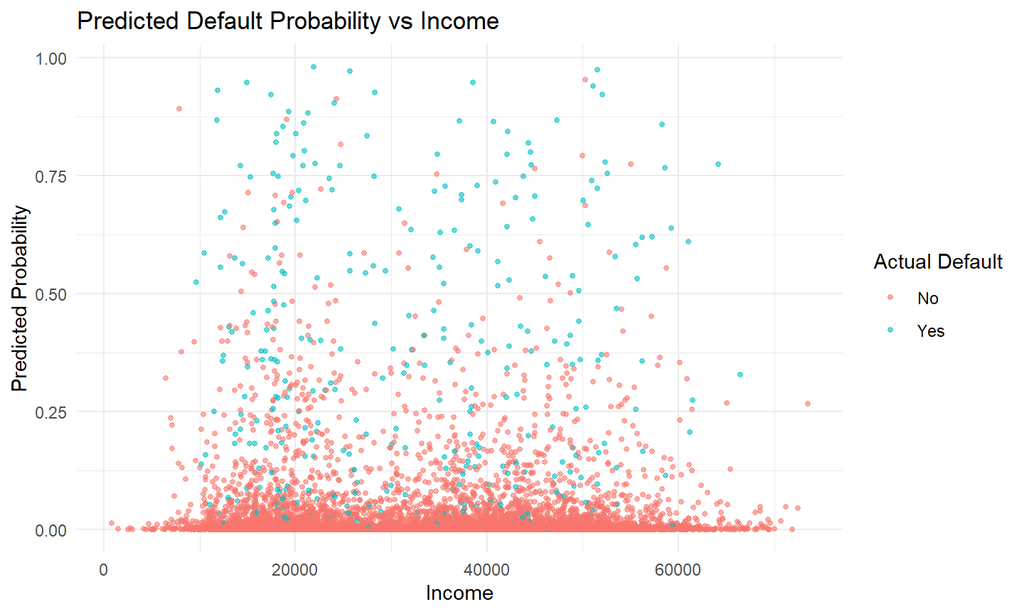

- Doesn’t seem to be much correlation between income and default
- Consistent with small coefficient

## Making Classifications

- Logistic regression outputs probabilities, but we need to assign classes (Yes/No)
- Common approach: choose threshold = 0.5
- If \(p > 0.5\), predict **Yes** (default), otherwise predict **No**
- Creates a **confusion matrix** comparing predicted vs actual values

```r
> Default$pred_logistic <- factor(ifelse(Default$prob_logistic>0.5,"Yes","No"), levels=c("No","Yes"))
>
> table(Predicted=Default$pred_logistic, Actual=Default$default)
         Actual
Predicted   No  Yes
      No  9629  225
      Yes   38  108
```

- We can also calculate performance metrics

```
  accuracy precision    recall specificity
1   0.9737  0.739726 0.3243243   0.9960691
```

## Threshold Selection

- The default 0.5 threshold may not be optimal
- Lower thresholds → more positives (higher recall, lower precision)
- Higher thresholds → fewer positives (higher precision, lower recall)
- Choice depends on the cost of errors:
  - Bank loans: better to avoid false negatives (catch more defaults)
  - Medical tests: better to avoid false positives (fewer unnecessary treatments)

```
  threshold precision     recall specificity
1       0.1 0.3018634 0.72972973   0.9418641
2       0.2 0.4246285 0.60060060   0.9719665
3       0.3 0.5307443 0.49249249   0.9850005
4       0.4 0.6616162 0.39339339   0.9930692
5       0.5 0.7397260 0.32432432   0.9960691
6       0.6 0.8000000 0.24024024   0.9979311
7       0.7 0.8169014 0.17417417   0.9986552
8       0.8 0.8437500 0.08108108   0.9994828
9       0.9 0.8461538 0.03303303   0.9997931
```

## Precision-Recall Tradeoff

- Precision and Recall usually move in opposite directions

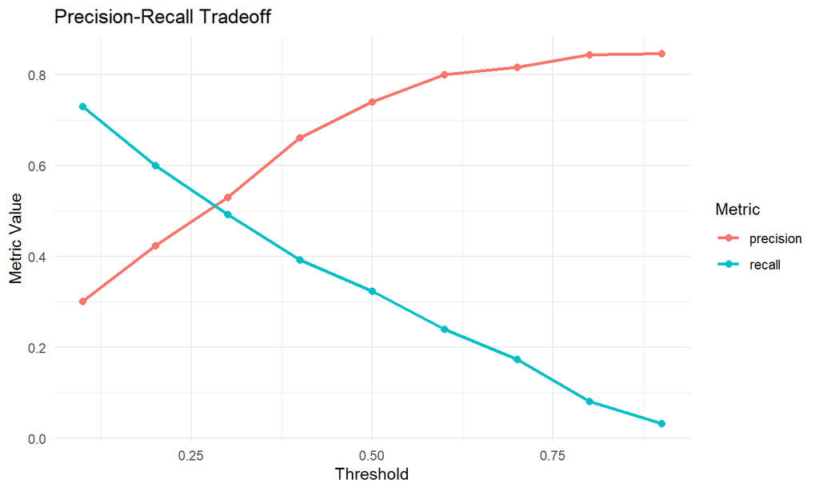

## ROC Curve Concept

- ROC curve: plots **True Positive Rate (Recall)** vs **False Positive Rate** across thresholds
- Helps visualize model’s ability to separate classes
- A model with no predictive power lies on the diagonal (random guessing)
- The closer the curve hugs the top-left, the better the model

```
   threshold       tpr         fpr
1       0.00 1.0000000 1.000000000
2       0.05 0.8468468 0.100134478
3       0.10 0.7297297 0.058135926
4       0.15 0.6726727 0.039205545
5       0.20 0.6006006 0.028033516
6       0.25 0.5555556 0.020585497
7       0.30 0.4924925 0.014999483
8       0.35 0.4594595 0.009827247
9       0.40 0.3933934 0.006930795
10      0.45 0.3453453 0.004965346
```

## ROC Curve Visualization

- The **AUC (Area Under Curve)** provides a single measure of performance:
  - AUC closer to 1 → strong predictive power

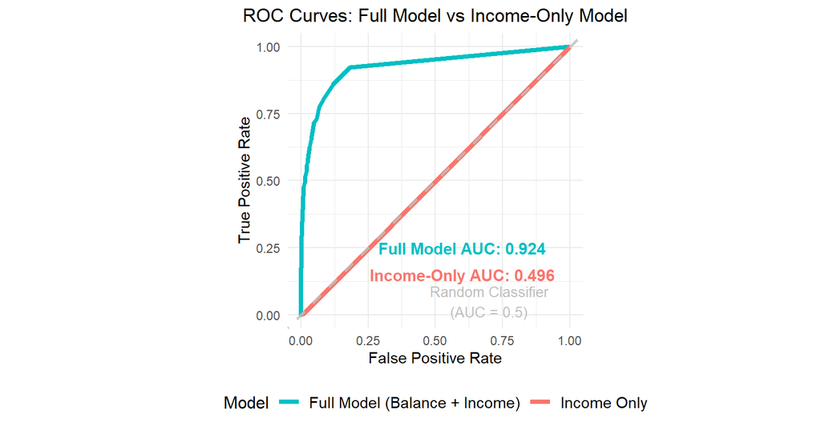

- Including `balance` is key and improves fit at every cutoff

## Visualizing Decision Boundary

- Let’s compare the non-optimizing cutoff rule vs logistic regression

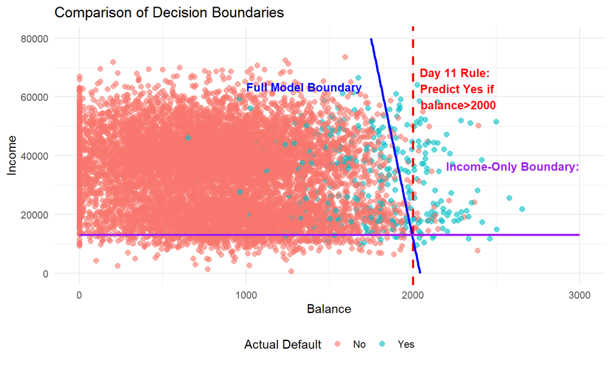

- Ultimate goal is to have a boundary that perfectly separates the colors

## Model comparison

**Performance Comparison:**

- **Simple Rule (Day 11):** Predict default if balance > 2000.
- **Logistic Regression (Full):** Uses both balance and income to predict default probabilities.
- **Logistic Regression (Income-Only):** Uses only income to predict default probabilities.

```
                     Accuracy  Precision     Recall Specificity   F1_Score
Rule_2000              0.9723 0.76415094 0.24324324   0.9974139 0.36902050
Logistic_Full          0.9737 0.73972603 0.32432432   0.9960691 0.45093946
Logistic_Income_Only   0.9383 0.02666667 0.02402402   0.9697941 0.02527646
```

**Insights:**

- Full logistic regression improves `F1 score` compared to the simple rule. Can tweak `precision`,`recall` by changing cutoff
- Full logistic regression uses multiple predictors, allowing for a **more nuanced decision boundary** than the simple rule or single-variable models.
- Reminder: Most of the data (96.7%) is no default so can get high accuracy by always predicting no

## Key Takeaways

**Key Takeaways from Logistic Regression:**

- **Probabilities over Classes:** Logistic regression predicts probabilities, not just Yes/No outcomes.
- **Interpretability:** Coefficients can be interpreted as **odds ratios**, showing the effect of predictors on the odds of the outcome.
- **Threshold Matters:** Choice of probability threshold impacts **precision, recall, and specificity**.
- **Performance Evaluation:** Use metrics like confusion matrix, ROC curve, and AUC to assess model performance.
- **Flexibility:** Multiple predictors allow for more nuanced decision boundaries compared to simple rules.
- **Visualization Helps:** Plotting probabilities and decision boundaries clarifies model behavior and trade-offs.